# Exploring Automated Machine Learning

### By: Matthew Spinelli

[figure not shown]

# First Looks at the Dataset

```python
import pandas as pd

df = pd.read_csv("data.csv")
df.head()
```

|  | id | label | f1 | f2 | f3 | c1 |
| --- | --- | --- | --- | --- | --- | --- |
| 0 | 299340 | 1 | 2.114135 | 53.279725 | 0.715891 | f |
| 1 | 222579 | 1 | 2.750729 | -68.723837 | 0.783546 | m |
| 2 | 152620 | -1 | -0.398702 | 37.517511 | 0.057790 | m |
| 3 | 201201 | -1 | 6.107160 | -178.689183 | -0.825741 | m |
| 4 | 268691 | 1 | 6.485862 | -157.894766 | 0.740175 | m |

Check for missing values or extreme values. It turns out the scales of the continuous features are quite different. It may be a good idea to normalize these depending on the model used.

```python
print(df.info(verbose=True))
df.iloc[1:].describe()
```

```
<class 'pandas.core.frame.DataFrame'>
RangeIndex: 100000 entries, 0 to 99999
Data columns (total 6 columns):
id       100000 non-null int64
label    100000 non-null int64
f1       100000 non-null float64
f2       100000 non-null float64
f3       100000 non-null float64
c1       100000 non-null object
dtypes: float64(3), int64(2), object(1)
memory usage: 4.6+ MB
None
```

|  | id | label | f1 | f2 | f3 |
| --- | --- | --- | --- | --- | --- |
| count | 99999.000000 | 99999.000000 | 99999.000000 | 99999.000000 | 99999.000000 |
| mean | 199893.024440 | -0.334293 | 0.996444 | -50.013200 | -0.000445 |
| std | 57668.536993 | 0.942474 | 3.464287 | 86.627756 | 0.578295 |
| min | 100000.000000 | -1.000000 | -4.999927 | -199.999115 | -0.999982 |
| 25% | 150168.000000 | -1.000000 | -2.009128 | -125.138030 | -0.502098 |
| 50% | 199789.000000 | -1.000000 | 1.000554 | -49.740820 | 0.000176 |
| 75% | 249787.500000 | 1.000000 | 3.993037 | 24.898066 | 0.500042 |
| max | 299994.000000 | 1.000000 | 6.999791 | 99.999832 | 0.999995 |

Convert the -1 and +1 label values to be `False` and `True` respectively to make it easier to work with (this is a binary classifier problem).

```python
df.set_index(keys=['id'], inplace=True)
df.label = df.label.map(lambda x: True if x==1 else False)
df.head()
```

| id | label | f1 | f2 | f3 | c1 |
| --- | --- | --- | --- | --- | --- |
| 299340 | True | 2.114135 | 53.279725 | 0.715891 | f |
| 222579 | True | 2.750729 | -68.723837 | 0.783546 | m |
| 152620 | False | -0.398702 | 37.517511 | 0.057790 | m |
| 201201 | False | 6.107160 | -178.689183 | -0.825741 | m |
| 268691 | True | 6.485862 | -157.894766 | 0.740175 | m |

Split the data into test, validation, and training sets before doing anything else to prevent data snooping and risk the ability to generalize well.

The validation compares different models without risk of overfitting since we have the test set to evaluate overall generalization performance once confident we've found a good model.

```python
rs = 123
from sklearn.model_selection import train_test_split

X_data, X_test, y_data, y_test = train_test_split(
    df.loc[:, df.columns != 'label'], df.label, shuffle=True,
    stratify=df.label, random_state=rs, test_size=0.25)

X_train, X_valid, y_train, y_valid = train_test_split(
    X_data, y_data, shuffle=True,
    stratify=y_data, random_state=rs, test_size=0.33)
```

# EDA

The data looks to be imbalanced with more False (-1) cases compared to True (+1).

```python
y_train.value_counts(normalize=True)
```

```
False    0.667124
True     0.332876
Name: label, dtype: float64
```

And there is and equal distribution of values accross the c1 categorical value of approximately 1/3 of observations falling into each one.

```python
X_train.c1.value_counts(normalize=True)
```

```
m    0.337393
n    0.334647
f    0.327960
Name: c1, dtype: float64
```

Visualize the data by plotting each pair of continuous variables (ignoring for them moment the categorical feature).

The classifications are color coded. Blue denotes False (-1) and yellow True (+1).

```python
import seaborn as sns

eda = X_train.copy()
eda['label'] = y_train

def plot_pairs(x, vars=['f1', 'f2', 'f3']):
    sns.pairplot(
        x, vars=vars, hue='label',
        plot_kws=dict(s=10, edgecolor='grey', linewidth=.1, alpha=.1),
        palette=sns.xkcd_palette(["navy blue", "faded yellow"]))

plot_pairs(eda);
```

[output not shown]

Features f1 and f3 have the most seperation power. But blue and yellow do overlap.

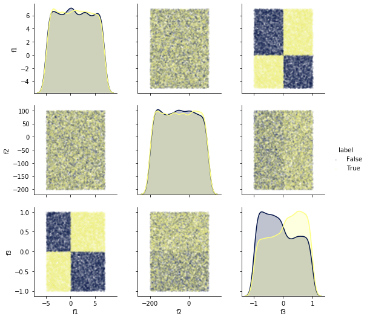

```python
plot_pairs(eda[eda.c1=='m']);
```

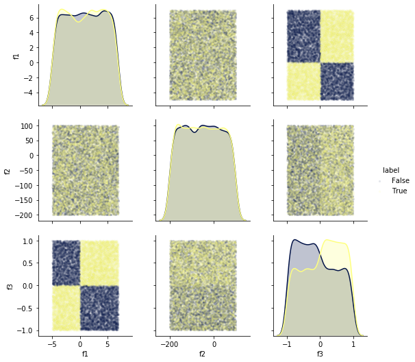

```python
plot_pairs(eda[eda.c1=='f']);
```

However, when `c1=='n'`, all observations appear to be False (-1).

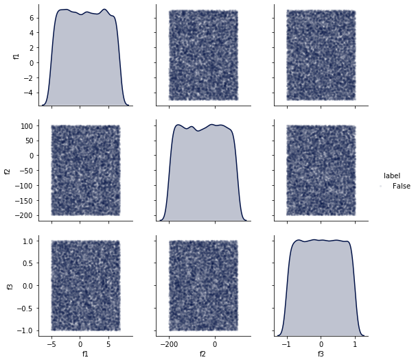

```python
plot_pairs(eda[eda.c1=='n']);
```

We need to transform the values `'m'`, `'f'`, and `'n'` to numbers (factors) to work with ML math.

```python
import numpy as np
from sklearn.preprocessing import LabelEncoder

le = LabelEncoder()
c1_encoder = le.fit(X_train.c1)

X_train.c1 = c1_encoder.transform(X_train.c1)
X_valid.c1 = c1_encoder.transform(X_valid.c1)
X_test.c1 = c1_encoder.transform(X_test.c1)
```

```python
X_train.head()
```

| id | f1 | f2 | f3 | c1 |
| --- | --- | --- | --- | --- |
| 220466 | 3.719200 | 38.883307 | 0.155112 | 0 |
| 192570 | -4.293955 | 41.388383 | 0.027261 | 1 |
| 267788 | -3.049226 | -190.471437 | -0.608987 | 1 |
| 175577 | 3.145266 | -152.071701 | -0.545764 | 2 |
| 217426 | -0.510158 | 21.682105 | -0.471217 | 2 |

# Modeling

Let's run a popular, statistical learning algorithm: logistic regression.

```python
from sklearn.ensemble import RandomForestClassifier
from sklearn.linear_model import LogisticRegression

clf = LogisticRegression(random_state=rs)
clf.fit(X_train, y_train)
cv = StratifiedKFold(n_splits=5, random_state=rs, shuffle=True)
```

```
Fold 1 results:
```

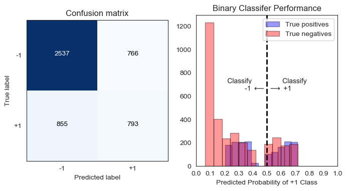

```python
for i, (_, indeces) in enumerate(cv.split(X_valid, y_valid)):
    print('Fold {0} results:'.format(i+1))
    cv_X = X_valid.iloc[indeces]
    cv_y = y_valid.iloc[indeces]
    sns.set_style("white")
    plot_results(clf, cv_X, cv_y)
    break
```

# Auto ML

```python
from tpot import TPOTClassifier

config_dict = {
    'sklearn.linear_model.LogisticRegression': {
        'penalty': ["l1", "l2"],
        'C': [1e-4, 1e-3, 1e-2, 1e-1, 0.5, 1., 5., 10., 15., 20., 25.],
        'dual': [True, False]
    },
    'sklearn.preprocessing.MinMaxScaler': {},
    'sklearn.preprocessing.StandardScaler': {},
}

tpot = TPOTClassifier(generations=5, population_size=4,
                      scoring='neg_log_loss',
                      early_stop = 3, config_dict=config_dict,
                      periodic_checkpoint_folder='./checkpoint_tpot',
                      n_jobs=8, cv=5, verbosity=2, random_state=rs)
tpot.fit(X_train, y_train)
print(tpot.score(X_valid, y_valid))
tpot.export('tpot_pipeline.py')
```

```
Generation 1 - Current best internal CV score: -0.5113433692341023
Generation 2 - Current best internal CV score: -0.5113433692341023
Generation 3 - Current best internal CV score: -0.5064424804351911
Generation 4 - Current best internal CV score: -0.4558452669021422
Generation 5 - Current best internal CV score: -0.4558452669021422

Best pipeline: LogisticRegression(LogisticRegression(LogisticRegression(StandardScaler(input_matrix), C=25.0, dual=False, penalty=l1), C=0.001, dual=False, penalty=l1), C=0.1, dual=False, penalty=l2)
-0.45385546147394146
```

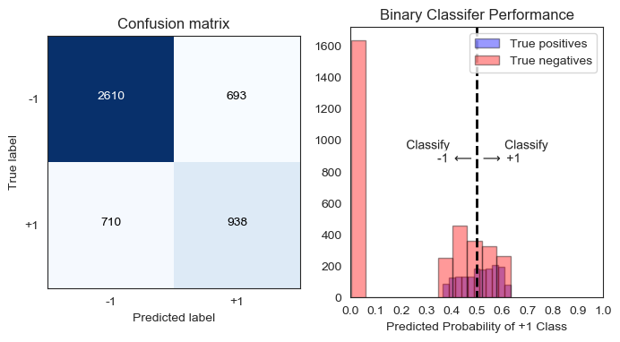

```python
for _, indeces in cv.split(X_valid, y_valid):
    cv_X = X_valid.iloc[indeces]
    cv_y = y_valid.iloc[indeces]
    sns.set_style("white")
    plot_results(tpot, cv_X, cv_y)
    break
```

The result are better, but this still isn't good. A logistic regression isn't a good model. Even when trying to scale the parameters to be comparable. We can run tpot wide open to explore more models.

```python
tpot = TPOTClassifier(generations=5, population_size=4,
                      scoring='neg_log_loss',
                      early_stop = 3,
                      periodic_checkpoint_folder='./checkpoint_tpot',
                      n_jobs=8, cv=5, verbosity=2, random_state=rs)
tpot.fit(X_train, y_train)
print(tpot.score(X_valid, y_valid))
tpot.export('tpot_pipeline.py')
```

```
Generation 1 - Current best internal CV score: -0.0001341758150675168
Generation 2 - Current best internal CV score: -0.0001341758150675168

The optimized pipeline was not improved after evaluating 3 more generations. Will end the optimization process.

TPOT closed prematurely. Will use the current best pipeline.

Best pipeline: DecisionTreeClassifier(input_matrix, criterion=gini, max_depth=10, min_samples_leaf=5, min_samples_split=18)
-0.001395506116967087
```

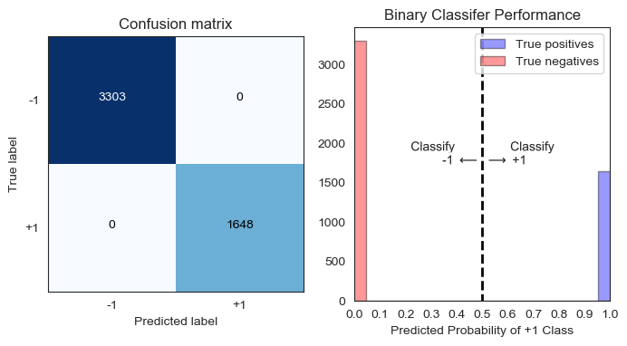

```python
for _, indeces in cv.split(X_valid, y_valid):
    cv_X = X_valid.iloc[indeces]
    cv_y = y_valid.iloc[indeces]
    sns.set_style("white")
    plot_results(tpot, cv_X, cv_y)
    break
```

The nice thing about a Decision Tree is we can verify the approach it's taking by looking at the tree itself. We'll do this with `graphviz`.

```python
from sklearn.tree import export_graphviz
clf = tpot.fitted_pipeline_.steps[0][1]
export_graphviz(clf, out_file='tree.dot')
```

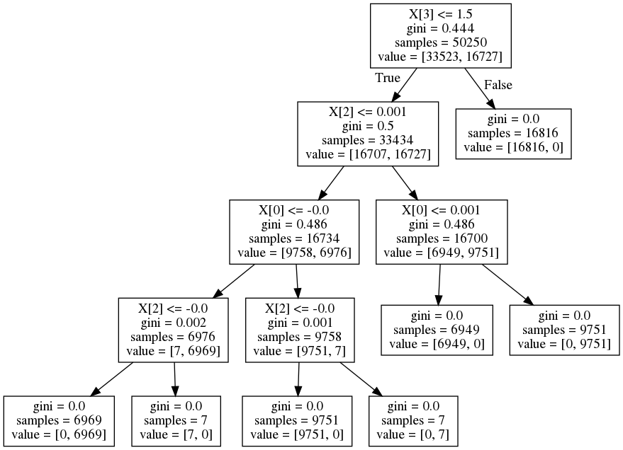

```python
!dot -Tpng tree.dot -o tree.png
from IPython.display import Image
Image('tree.png')
```

# Test for Generalization

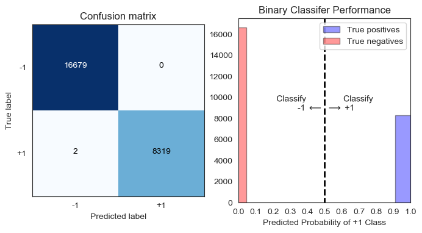

```python
plot_results(tpot, X_test, y_test)
```